# Climbing Project

## BEE2041: Data Science in Economics

#### University of Exeter Business School

#### Student Number: 730056011

#### Module Convenor: Damian Clarke

#### Due Date + Extension: 1st May 15:00 (GMT)

### Notes (Please Read)

This Jupyter notebook is where I ran all the python code and did all the processing and work for this project.

Whilst this notebook does indeed include the majority of the writeup for the blogpost (unless you are viewing the code only version), I have published it properly using the below link which may be easier to view with the proper formatting and structure of a blog post.

Blog Link: https://8-7publication2015-2016.blogspot.com/2025/04/what-climbers-really-love-analysing.html

## What Climbers Really Love: Analysing Ratings and Grades at America’s Iconic Bouldering Areas

### Introduction

Bouldering is one of the purest and most dynamic forms of climbing, a discipline built around short, powerful sequences that test strength, technique, and creativity. Done without ropes but protected by mats, it’s a style that invites both beginners and experts alike to push their limits on the rock.

In this project, I explore how difficulty and popularity interact across three of the most iconic U.S. bouldering areas: Hueco Tanks, Joe’s Valley, and Joshua Tree. Each has its own flavour — from Hueco’s steep, pocketed problems, to Joe’s Valley’s diverse sandstone, to Joshua Tree’s old-school slabs and highballs. These differences shape not only how climbs feel but also how they’re graded and perceived.

Using data from MountainProject.com, I ask:

- How are climbs distributed across the V-grade scale in each region?
- Do climbers prefer easier problems, or are harder lines more beloved?
- Are rating trends and difficulty distributions consistent across areas?

As both a climber and an economics student, this analysis is not just a data exercise, but a way to understand how climbers engage with the environments they love — and what makes a boulder problem truly memorable

```python
# Import libraries
import pandas as pd
import matplotlib.pyplot as plt
import seaborn as sns
import statsmodels.formula.api as smf
import re
import numpy as np
from sklearn.model_selection import train_test_split
from sklearn.linear_model import LinearRegression
from sklearn.preprocessing import OneHotEncoder
from sklearn.compose import ColumnTransformer
from sklearn.pipeline import Pipeline
from sklearn.metrics import mean_squared_error, r2_score
```

```python
# Configure
sns.set(style = "whitegrid")
```

### Data & Caveats

For this analysis, I used data from MountainProject.com — a popular, community-driven climbing platform where climbers log ascents and rate routes. By focusing on the chosen US bouldering areas — Hueco Tanks, Joe’s Valley, and Joshua Tree — I aim to explore how difficulty and popularity intersect across these regions.

One key variable is the number of ratings a climb receives. A 4-star route with 200 votes tells us more than one with a single rating, so popularity helps gauge consensus.

That said, there are a few things to keep in mind:

- Grades are subjective: A V5 in Joshua Tree might feel very different from a V5 in Joe’s Valley, so comparisons can be tricky.
- Crowd Sourced Bias: The ratings are crowd-sourced, meaning they’re influenced by individual climbers’ experiences, which can vary depending on factors like season, visibility, and popularity.
- Uneven Sampling: While Hueco has a lot of climbs with plenty of ratings, the others have more obscure climbs with just a handful of ratings, something we account for when interpreting results.

Ultimately, the goal here is to understand not just what’s hard or easy, but what climbers truly enjoy.

```python
# Load and check CSV's
df_joshua = pd.read_csv("/Users/sam/Desktop/climbing_project/project_files/data/joshua_tree.csv")
df_joe = pd.read_csv("/Users/sam/Desktop/climbing_project/project_files/data/joes_valley.csv")
df_hueco = pd.read_csv("/Users/sam/Desktop/climbing_project/project_files/data/hueco_tanks.csv")
```

```python
df_joshua.head(10)
```

|  | Route | Location | URL | Avg Stars | Num Ratings | Your Stars | Route Type | Rating | Pitches | Length | Area Latitude | Area Longitude |
| --- | --- | --- | --- | --- | --- | --- | --- | --- | --- | --- | --- | --- |
| 0 | White Rastafarian | White Rastafarian Boulder > Outback Bouldering... | https://www.mountainproject.com/route/10572259... | 3.9 | 291 | -1 | Boulder | V2 R | 1 | 20.0 | 34.02066 | -116.16208 |
| 1 | Slashface | Slash Boulder > Western Belt > Geology Tour Ro... | https://www.mountainproject.com/route/10572275... | 3.9 | 130 | -1 | Boulder | V3 R | 1 | 25.0 | 33.95344 | -116.08706 |
| 2 | Pigpen | Pigpen Boulder > Manx Boulders Circuit > Manx/... | https://www.mountainproject.com/route/10572299... | 3.9 | 229 | -1 | Boulder | V4 | 1 | 10.0 | 34.01530 | -116.15811 |
| 3 | JBMFP | JBMF Boulder > JBMF Boulders > Roadside Rocks ... | https://www.mountainproject.com/route/10572546... | 3.9 | 239 | -1 | Boulder | V5 | 1 | 16.0 | 34.01520 | -116.16631 |
| 4 | Gunsmoke | Gunsmoke Wall > Gunsmoke Area > Barker Dam Bou... | https://www.mountainproject.com/route/10572235... | 3.7 | 527 | -1 | Boulder | V3 | 1 | 80.0 | 34.02858 | -116.14508 |
| 5 | Stem Gem | Stem Gem Boulder > HVCG West > HVCG Bouldering... | https://www.mountainproject.com/route/10572260... | 3.8 | 268 | -1 | Boulder | V4 | 1 | 20.0 | 34.01716 | -116.16368 |
| 6 | Fry Problem | Fry Boulder > Fry Boulders > Stonehenge and Fr... | https://www.mountainproject.com/route/10603937... | 3.7 | 192 | -1 | Boulder | V2 | 1 | 15.0 | 33.98831 | -116.15795 |
| 7 | False Up 20 | False Up 20 Boulder > JBMF Boulders > Roadside... | https://www.mountainproject.com/route/10572546... | 3.6 | 238 | -1 | Boulder | V0- | 1 | 20.0 | 34.01513 | -116.16605 |
| 8 | Saturday Night Live | Saturday Night Live Boulder > Real Hidden Vall... | https://www.mountainproject.com/route/10572351... | 3.6 | 186 | -1 | Boulder | V4 | 1 | 13.0 | 34.01167 | -116.16855 |
| 9 | The Chube | Chube Boulder > Gunsmoke Area > Barker Dam Bou... | https://www.mountainproject.com/route/10572444... | 3.4 | 400 | -1 | Boulder | V2 | 1 | 15.0 | 34.02838 | -116.14524 |

```python
# Add location column for each
df_joshua["Location"] = "Joshua Tree"
df_joe["Location"] = "Joe's Valley"
df_hueco["Location"] = "Hueco Tanks"
```

```python
# Combine into one dataframe
df_all = pd.concat([df_joshua, df_joe, df_hueco], ignore_index = True)
```

```python
# Get rid of redundant columns
columns_to_drop = ['URL', 'Your Stars', 'Route Type', 'Length', 'Pitches',]
df_all = df_all.drop(columns = columns_to_drop)
```

```python
# Quick View
df_all
```

|  | Route | Location | Avg Stars | Num Ratings | Rating | Area Latitude | Area Longitude |
| --- | --- | --- | --- | --- | --- | --- | --- |
| 0 | White Rastafarian | Joshua Tree | 3.9 | 291 | V2 R | 34.02066 | -116.16208 |
| 1 | Slashface | Joshua Tree | 3.9 | 130 | V3 R | 33.95344 | -116.08706 |
| 2 | Pigpen | Joshua Tree | 3.9 | 229 | V4 | 34.01530 | -116.15811 |
| 3 | JBMFP | Joshua Tree | 3.9 | 239 | V5 | 34.01520 | -116.16631 |
| 4 | Gunsmoke | Joshua Tree | 3.7 | 527 | V3 | 34.02858 | -116.14508 |
| ... | ... | ... | ... | ... | ... | ... | ... |
| 2485 | V0 Runnel | Hueco Tanks | 2.0 | 1 | V0 | 31.91559 | -106.04608 |
| 2486 | V1 Vert | Hueco Tanks | 2.0 | 2 | V1 | 31.91559 | -106.04608 |
| 2487 | V2 Huecos | Hueco Tanks | 2.5 | 2 | V2 | 31.91559 | -106.04608 |
| 2488 | Pink Moon | Hueco Tanks | 3.0 | 2 | V5 | 31.91563 | -106.04213 |
| 2489 | Roses are Red | Hueco Tanks | 3.0 | 1 | V9 | 31.91563 | -106.04213 |

2490 rows × 7 columns

```python
# Clean up the grades into workable integers
def clean_v_grade(grade_str):
    match = re.match(r"V(\d+)", str(grade_str))
    return int(match.group(1)) if match else None

# Example usage on a DataFrame column
df_all['Numeric_Grade'] = df_all['Rating'].apply(clean_v_grade)
df_all = df_all.dropna(subset = ["Numeric_Grade", "Avg Stars"])
df_all
```

|  | Route | Location | Avg Stars | Num Ratings | Rating | Area Latitude | Area Longitude | Numeric_Grade |
| --- | --- | --- | --- | --- | --- | --- | --- | --- |
| 0 | White Rastafarian | Joshua Tree | 3.9 | 291 | V2 R | 34.02066 | -116.16208 | 2.0 |
| 1 | Slashface | Joshua Tree | 3.9 | 130 | V3 R | 33.95344 | -116.08706 | 3.0 |
| 2 | Pigpen | Joshua Tree | 3.9 | 229 | V4 | 34.01530 | -116.15811 | 4.0 |
| 3 | JBMFP | Joshua Tree | 3.9 | 239 | V5 | 34.01520 | -116.16631 | 5.0 |
| 4 | Gunsmoke | Joshua Tree | 3.7 | 527 | V3 | 34.02858 | -116.14508 | 3.0 |
| ... | ... | ... | ... | ... | ... | ... | ... | ... |
| 2485 | V0 Runnel | Hueco Tanks | 2.0 | 1 | V0 | 31.91559 | -106.04608 | 0.0 |
| 2486 | V1 Vert | Hueco Tanks | 2.0 | 2 | V1 | 31.91559 | -106.04608 | 1.0 |
| 2487 | V2 Huecos | Hueco Tanks | 2.5 | 2 | V2 | 31.91559 | -106.04608 | 2.0 |
| 2488 | Pink Moon | Hueco Tanks | 3.0 | 2 | V5 | 31.91563 | -106.04213 | 5.0 |
| 2489 | Roses are Red | Hueco Tanks | 3.0 | 1 | V9 | 31.91563 | -106.04213 | 9.0 |

2315 rows × 8 columns

```python
# View the info
df_all.info()
```

```
<class 'pandas.core.frame.DataFrame'>
Int64Index: 2315 entries, 0 to 2489
Data columns (total 8 columns):
 #   Column          Non-Null Count  Dtype
---  ------          --------------  -----
 0   Route           2315 non-null   object
 1   Location        2315 non-null   object
 2   Avg Stars       2315 non-null   float64
 3   Num Ratings     2315 non-null   int64
 4   Rating          2315 non-null   object
 5   Area Latitude   2315 non-null   float64
 6   Area Longitude  2315 non-null   float64
 7   Numeric_Grade   2315 non-null   float64
dtypes: float64(4), int64(1), object(3)
memory usage: 162.8+ KB
```

```python
# Create a filtered data set that include only routes with Avg Stars >= 0 -- Used for ratings related graphs
df_filtered = df_all[df_all["Avg Stars"] >= 0]
df_filtered.head(10)
```

|  | Route | Location | Avg Stars | Num Ratings | Rating | Area Latitude | Area Longitude | Numeric_Grade |
| --- | --- | --- | --- | --- | --- | --- | --- | --- |
| 0 | White Rastafarian | Joshua Tree | 3.9 | 291 | V2 R | 34.02066 | -116.16208 | 2.0 |
| 1 | Slashface | Joshua Tree | 3.9 | 130 | V3 R | 33.95344 | -116.08706 | 3.0 |
| 2 | Pigpen | Joshua Tree | 3.9 | 229 | V4 | 34.01530 | -116.15811 | 4.0 |
| 3 | JBMFP | Joshua Tree | 3.9 | 239 | V5 | 34.01520 | -116.16631 | 5.0 |
| 4 | Gunsmoke | Joshua Tree | 3.7 | 527 | V3 | 34.02858 | -116.14508 | 3.0 |
| 5 | Stem Gem | Joshua Tree | 3.8 | 268 | V4 | 34.01716 | -116.16368 | 4.0 |
| 6 | Fry Problem | Joshua Tree | 3.7 | 192 | V2 | 33.98831 | -116.15795 | 2.0 |
| 7 | False Up 20 | Joshua Tree | 3.6 | 238 | V0- | 34.01513 | -116.16605 | 0.0 |
| 8 | Saturday Night Live | Joshua Tree | 3.6 | 186 | V4 | 34.01167 | -116.16855 | 4.0 |
| 9 | The Chube | Joshua Tree | 3.4 | 400 | V2 | 34.02838 | -116.14524 | 2.0 |

### Comparing Difficulty Distributions Across Regions

The spread of bouldering difficulty in a climbing area reveals a lot about its character — whether it's a playground for beginners or a proving ground for seasoned crushers. By comparing the distributions in Hueco Tanks, Joe’s Valley, and Joshua Tree, we get a clearer sense of what each area offers and how it caters to different types of climbers.

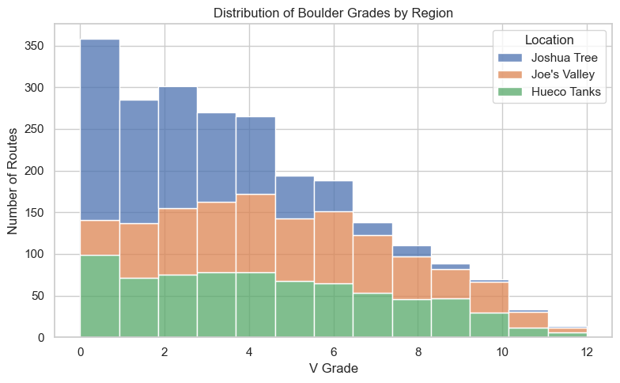

```python
# Plot: Histogram of grades
plt.figure(figsize = (8, 5))
sns.histplot(df_all, x = "Numeric_Grade", hue = "Location", multiple = "stack", bins = 13)
plt.title("Distribution of Boulder Grades by Region")
plt.xlabel("V Grade")
plt.ylabel("Number of Routes")
plt.tight_layout()
plt.show()
```

Across all three areas, its clear that the number of routes generally declines as difficulty increases, which makes sense. Harder climbs take more effort to establish, and naturally, there are fewer of them. But the pace at which that decline happens, and the exact spread of difficulty, tells a more nuanced story.

#### Joshua Tree

This area stands out as the most beginner-friendly. There’s a dense cluster of V0–V2 problems, but a sharp drop beyond that. You won’t find many climbs above V5. It’s not a hotspot for cutting-edge difficulty, but its classic easy problems and scenic desert setting make it a favourite for newer climbers or those seeking mellow days.

#### Joe’s Valley

Joe’s Valley, on the other hand, offers a more balanced spread. From V2 to V8, there's a solid spread, with mid-range grades being particularly dominant. This makes it one of the most versatile areas in the dataset, with enough variety to challenge climbers across a wide skill range. Whether you’re still working through V2s or pushing for V8, there’s something here for you.

### What Climbers Are Actually Climbing

Knowing how climbs are graded is one thing — but what are climbers actually getting on? To answer that, we turn to the number of logged ascents at each grade. This serves as a useful proxy for popularity and usage.

Whereas the previous section focused on what's available, we now want to look at what’s actually getting climbed. By plotting total ratings per V-grade, we see where climbers are spending their time — and how that differs between areas.

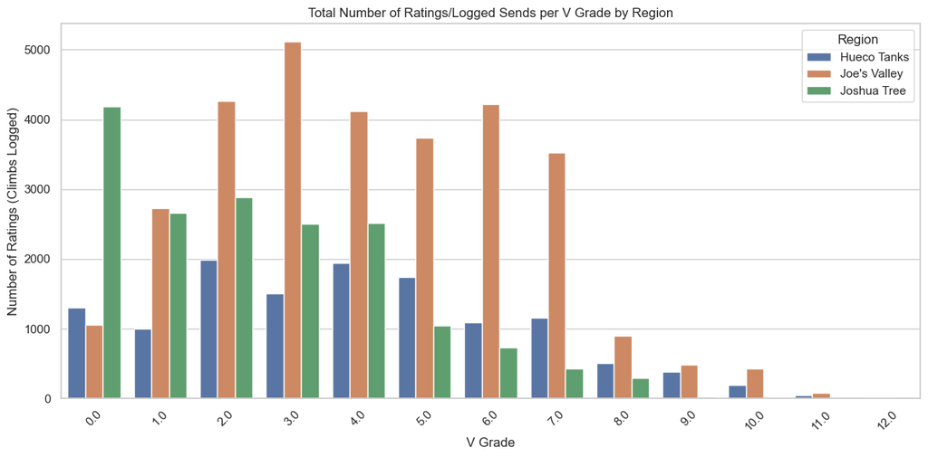

```python
# Group by grade and location, summing number of ratings
ratings_per_grade = df_all.groupby(['Numeric_Grade', 'Location'])['Num Ratings'].sum().reset_index()

# Set up the plot
plt.figure(figsize = (12, 6))
sns.barplot(
    data = ratings_per_grade,
    x = 'Numeric_Grade',
    y = 'Num Ratings',
    hue = 'Location'
)

plt.title("Total Number of Ratings/Logged Sends per V Grade by Region")
plt.xlabel("V Grade")
plt.ylabel("Number of Ratings (Climbs Logged)")
plt.xticks(rotation = 45)
plt.legend(title = "Region")
plt.tight_layout()
plt.show()
```

Unsurprisingly, most of the action across all three areas is in the V0–V6 range. That tracks with broader trends in climbing as these grades are the most accessible, abundant, and where most climbers operate. But each region shows its own patterns:

#### Joshua Tree

Joshua Tree sees the most logged ascents at V0, with V1 to V4 also receiving considerable attention. However, from V5 onwards, activity tapers off quickly, with very few logs beyond V8. This aligns with the area’s beginner-friendly profile — it’s a place for early progression and mileage rather than elite pushing.

#### Hueco Tanks

Hueco follows a similar pattern to Joe’s, though with relatively more activity at V0 and V1. The decline in logged ascents is more gradual, suggesting a broader and more continuous spread of difficulty levels being climbed. This supports Hueco’s reputation as both an entry point and a legendary testpiece venue — its easier problems draw in the crowds, while its harder classics see selective but steady traffic.

Together, the spread of grades and the volume of logged ascents give us a fuller picture of how these areas are used. With that context, we can now ask: which climbs are the most beloved — and does difficulty influence how routes are rated?

### Do Climbers Prefer Easier Routes?

With this in mind, we can now ask: when choosing climbs, do people gravitate toward fun, approachable boulders — or chase the challenge and prestige of something harder? To explore this, we can look at the relationship between a route’s difficulty and its average user rating across the three regions.

#### Why This Matters

Climber satisfaction isn’t just about difficulty — it’s about experience. Do climbers reward approachable, enjoyable climbs with high ratings, or do they save their stars for the hardest lines? These patterns reveal deeper insights about motivation, risk tolerance, and the way we relate to different climbing environments.

Each point in the below scatter plot represents a route. The x-axis shows difficulty (V grade), the y-axis shows average user rating (out of 4 stars), and point size reflects how many climbers have logged the route.

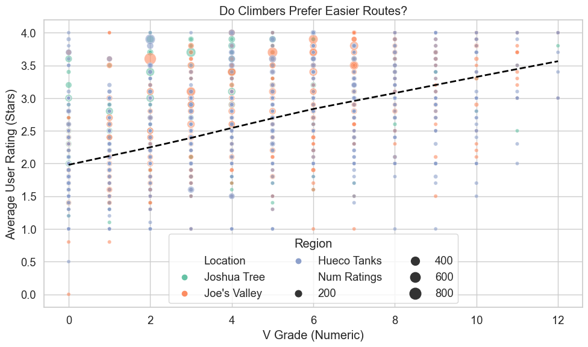

```python
# Set a consistent plot style
sns.set(style = "whitegrid", font_scale = 1.2)

# Create scatterplot: difficulty (Numeric_Grade) vs average user rating
plt.figure(figsize = (10, 6))
scatter = sns.scatterplot(
    data = df_filtered,
    x = "Numeric_Grade",
    y = "Avg Stars",
    hue = "Location",
    size = "Num Ratings",  # Size based on number of ratings
    sizes = (20, 200),     # Adjust the range of point sizes as needed
    palette = "Set2",
    alpha = 0.6          # Slight transparency to help with overlapping
)

# Add smoothing trend line
sns.regplot(
    data = df_filtered,
    x = "Numeric_Grade",
    y = "Avg Stars",
    scatter = False,
    lowess = True,
    color = "black",
    line_kws = {'linewidth': 2, 'linestyle': 'dashed'}
)

plt.title("Do Climbers Prefer Easier Routes?")
plt.xlabel("V Grade (Numeric)")
plt.ylabel("Average User Rating (Stars)")
plt.legend(title = "Region", loc = 'lower center', bbox_to_anchor = (0.5, -0.005), ncol = 3) # changed the location of the legend
plt.tight_layout()
plt.show()
```

#### What the Scatter Plot Tells Us

#### Challenging climbs often earn more love.

Its not dramatic, but there’s a slight upward slope in average ratings as difficulty increases, suggesting climbers reward climbs that test them.

#### Popular ≠ well-loved

Some of the most-climbed problems (especially in the V0–V4 range) receive average ratings. It seems volume doesn’t always mean praise.

#### Quality varies at every grade

From beginner-friendly V1s to gnarly V9s, star ratings swing wildly. The best routes aren’t defined by grade, but by experience.

#### Crowding in lower grades

The scatter plot is densest in the V0–V4 range, where most climbs — and climbers — live. Larger point sizes here help surface the most influential problems.

#### Regional flavour matters

To go deeper, I broke the data into box plots by grade and region. Each box shows the median rating and the spread of user scores — letting us compare consistency, variability, and overall enjoyment.

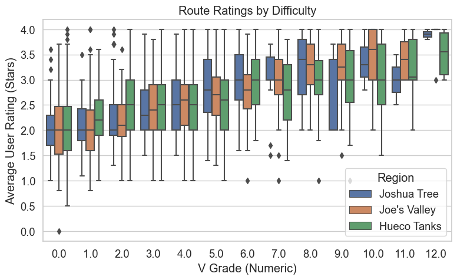

```python
# Plot: Route Ratings by Difficulty
plt.figure(figsize = (8, 5))
sns.boxplot(data = df_filtered, x = "Numeric_Grade", y = "Avg Stars", hue = "Location")

plt.title("Route Ratings by Difficulty")
plt.xlabel("V Grade (Numeric)")
plt.ylabel("Average User Rating (Stars)")
plt.legend(title = "Region")
plt.tight_layout()
plt.show()
```

Once again, ratings rise with difficulty. Especially from V0 to V8. Easier climbs (V0–V2) tend to score below 2.5 stars; harder ones edge closer to 3.

#### Joshua Tree

Mid-grade sweet spot. Joshua Tree’s V4–V8 climbs show a small but noticeable bump — combining challenge with broad appeal.

#### Grade ≠ quality

The biggest takeaway? A V6 isn’t automatically better than a V3. Great climbs come in all flavours.

#### Subjectivity rules

The spread in lower grades is especially wide — from beloved to loathed. Ratings are about experience, not just effort.

So, do climbers prefer easier climbs? Not necessarily. There’s a subtle lean toward rewarding harder climbs — but difficulty alone doesn’t guarantee praise. The climbs that resonate most tend to offer something more: flow, beauty, movement, or just a feeling that sticks with you long after the pads are packed away.

### Multiple Linear Regression Model Results: Interpreting the Output

So can we predict what climbers will enjoy? So far, we’ve looked at trends in difficulty, popularity, and ratings across regions — but what if we could go one step further? In this section, we build a multiple linear regression model to predict the average user rating of a climb based on its characteristics (climb’s difficulty, its location, and the number of ratings it received). The goal: to identify which features — from difficulty to location — actually influence how well a route is received.

```
R² Score: 0.3049798367708493
RMSE: 0.6379321467402654
```

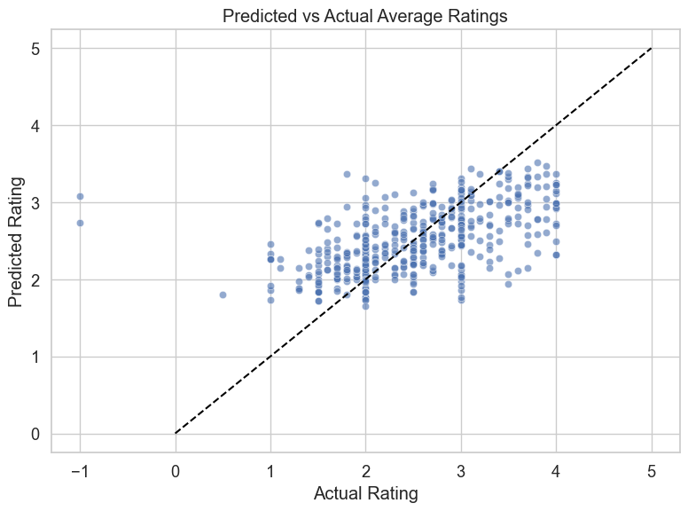

```
                 Feature  Coefficient
1        Log_Num_Ratings     0.165496
0          Numeric_Grade     0.132995
3   Location_Joshua Tree     0.035083
2  Location_Joe's Valley    -0.076674
```

```python
# Select features and target
df_model = df_all.copy()
df_model = df_model[df_model["Avg Stars"].notnull()]  # Drop missing ratings

# Log-transform number of ratings to reduce skew
df_model["Log_Num_Ratings"] = np.log1p(df_model["Num Ratings"])

# One-hot encode 'Location'
df_encoded = pd.get_dummies(df_model[["Numeric_Grade", "Log_Num_Ratings", "Location"]], drop_first=True)

# Define X and y
X = df_encoded
y = df_model["Avg Stars"]

# Train-test split
X_train, X_test, y_train, y_test = train_test_split(X, y, test_size = 0.2, random_state = 42)

# Fit linear regression
model = LinearRegression()
model.fit(X_train, y_train)

# Predict
y_pred = model.predict(X_test)

# Evaluate
print("R² Score:", r2_score(y_test, y_pred))
print("RMSE:", np.sqrt(mean_squared_error(y_test, y_pred)))

# Plot predicted vs actual
plt.figure(figsize = (8,6))
sns.scatterplot(x = y_test, y = y_pred, alpha = 0.6)
plt.plot([0, 5], [0, 5], linestyle = "--", color = "black")
plt.xlabel("Actual Rating")
plt.ylabel("Predicted Rating")
plt.title("Predicted vs Actual Average Ratings")
plt.tight_layout()
plt.show()

# Coefficients
coef_df = pd.DataFrame({
    "Feature": X.columns,
    "Coefficient": model.coef_
}).sort_values(by = "Coefficient", ascending=False)

print(coef_df)
```

##### R² Score: 0.305

The model explains 30.5% of the variance in average ratings. ➤ That’s decent for behavioural or preference data, which often contains a lot of noise — but it also indicates there’s still a good deal of unexplained variance, likely due to unmeasured factors (e.g. route aesthetics, scenery, movement quality, beta videos, etc.).

On a rating scale that likely ranges from 0 to 5 stars, this is a moderate error — not terrible, but it suggests predictions are typically off by around 0.64 stars.

🧠 Feature Coefficients (Interpretation)

##### Log_Num_Ratings +0.165

Climbs with more ratings tend to be rated higher, even after controlling for other factors. Popularity might signal quality or classic status.

##### Numeric_Grade +0.133

Harder climbs receive slightly higher ratings on average — consistent with our scatterplot analysis.

##### Location_Joshua Tree +0.035

After accounting for difficulty and popularity, climbs in Joshua Tree receive slightly higher ratings than those in Hueco Tanks (the baseline location).

##### Location_Joe's Valley −0.077

Climbs in Joe’s Valley tend to receive slightly lower ratings than those in Hueco Tanks, all else equal.

📝 Note: Hueco Tanks is the baseline in this regression because it’s omitted from the one-hot encoded location dummies. All location coefficients are interpreted relative to it.

### What This Tells Us

- There’s evidence that both difficulty and popularity influence user ratings.
- The effect of region exists, but it’s smaller than the effects of difficulty and number of ratings.
- Joe’s Valley appears to be slightly undervalued in user ratings compared to the other two, even after adjusting for grade and popularity.
- Joshua Tree has a slight premium, though the effect size is small.

Overall, Difficulty and popularity matter — and regional identity adds nuance — but the majority of what makes a climb beloved remains subjective.

### Top Rated Climbs in Joe’s Valley by Difficulty

To highlight what climbers truly love, we’ve zoomed in on Joe’s Valley, one of the most climb rich areas in the dataset. For each category, we list the top 10 highest-rated climbs based on average user ratings. Only routes with 10 or more ratings were considered to ensure reliability.

```python
# Filter the entire dataset for routes with at least 10 ratings
df_rating = df_all[df_all["Num Ratings"] >= 10]

# Filter data for Joe's Valley from the already filtered dataset
joes_valley_routes = df_rating[df_rating["Location"] == "Joe's Valley"]

# Beginner: V0 to V4
beginner_routes = joes_valley_routes[(joes_valley_routes['Numeric_Grade'] >= 0) & (joes_valley_routes['Numeric_Grade'] <= 4)]
top_beginner = beginner_routes.sort_values("Avg Stars", ascending=False).head(10)
print("\nTop Rated Beginner Routes (V0–V4):\n", top_beginner[["Route", "Avg Stars", "Num Ratings", "Rating"]])

# Intermediate: V5 to V8
intermediate_routes = joes_valley_routes[(joes_valley_routes['Numeric_Grade'] >= 5) & (joes_valley_routes['Numeric_Grade'] <= 8)]
top_intermediate = intermediate_routes.sort_values("Avg Stars", ascending=False).head(10)
print("\nTop Rated Intermediate Routes (V5–V8):\n", top_intermediate[["Route", "Avg Stars", "Num Ratings", "Rating"]])

# Advanced: V9 and above
advanced_routes = joes_valley_routes[joes_valley_routes['Numeric_Grade'] >= 9]
top_advanced = advanced_routes.sort_values("Avg Stars", ascending=False).head(10)
print("\nTop Rated Advanced Routes (V9+):\n", top_advanced[["Route", "Avg Stars", "Num Ratings", "Rating"]])
```

```
Top Rated Beginner Routes (V0–V4):
                      Route  Avg Stars  Num Ratings Rating
1337            Kobra Khan        4.0          202     V4
1419          Michelangelo        3.8          160   V3 R
1477                 Speed        3.7           48   V3 R
1462              Thriller        3.7          108   V0 R
1196            The Angler        3.6          902     V2
1341            The Kraken        3.6           37   V4 R
1231  America's Playground        3.6          128   V1-2
1681           Candy Paint        3.6           37     V3
1365           Wax or Wane        3.5           34     V4
1151          Sandy Cheeks        3.5           22     V4

Top Rated Intermediate Routes (V5–V8):
                            Route  Avg Stars  Num Ratings Rating
```

[output cut: 23 more lines]

### Wrapping It Up

Digging into the ratings of bouldering routes across some of the world’s most iconic climbing areas has been a fun ride — and it turns out, climbers aren’t just chasing the hardest grades. Sure, there’s a general trend: harder routes tend to get slightly higher ratings, but that’s far from the whole story. Some lower-grade problems still shine — especially when they’re interesting, aesthetic, or just plain fun.

Even when we tried to model what makes a route highly rated, the results were pretty humble — suggesting that while things like difficulty and popularity matter a bit, they definitely don’t tell the whole tale. Climbing is personal, and much of what makes a route memorable simply isn’t captured by the data.

Zooming in on Joe’s Valley with its big spread of routes across all grades gave us a great chance to see which climbs really stand out, from beginner classics like The Angler to steep test pieces like Wills of Fire. What binds them is the experience: the movement, the setting, the story. Ratings hint at consensus, but behind each star lies something personal.

In the end, this wasn’t just about finding “the best” routes — it was about celebrating how diverse, subjective, and opinionated the climbing community can be. Whether you’re projecting V12s or psyched on a chill V2 with a great view, there’s something out there that’s four stars in your book — and that’s what really counts.

Climbing isn’t just about difficulty. It’s about connection. To the rock. To the line. But most importantly, to the moment.